# Estudio de personas con discapacidad en el año 2012

### **ANALISIS PROBABILISTICO**

Analizando la variable genero, si se requiere realizar una entrevista al azar a un participante y se desea saber cual es la probabilidad de que sea del genero masculino. Tendremos que obtener la cantidad total de las personas y posteriormente hallar las probabilidades correspondientes.

```r
# Total de personas
total_personas <- (EDP %>% nrow())
total_personas
```

```
## [1] 1649
```

```r
# Total de personas del genero masculino
cantidad_hombres <- (EDP %>% filter(Genero == 'Hombre') %>% nrow())
cantidad_hombres
```

```
## [1] 941
```

Mediante este gráfico podemos analizar de mejor manera la variable género

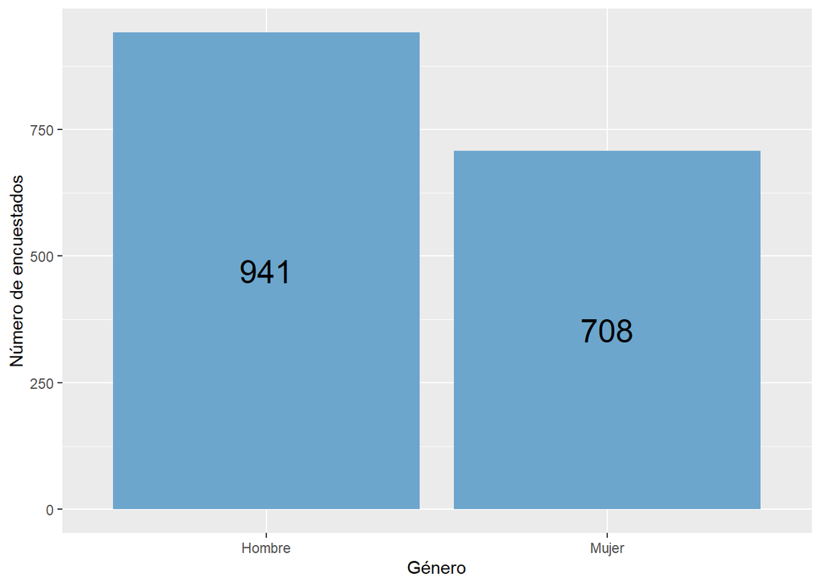

```r
ED %>% ggplot(aes(ED$Genero)) +
  geom_bar(fill="skyblue3") +
  stat_count(geom = "text", colour = "black", size = 7,
  aes(label = ..count..),position=position_stack(vjust=0.5)) +
  labs(x="Género",y="Número de encuestados")+
  theme(plot.title = element_text(hjust = 0.4))
```

Teniendo la cantidad total de personas del genero masculino, podemos hallar la probabilidad:
$$P(A)=
\frac{941}{1649}=0.5706489$$

```r
#
P1<-(EDP %>% filter(Genero == 'Hombre') %>% nrow())/(EDP %>% nrow())
P1
```

```
## [1] 0.5706489
```

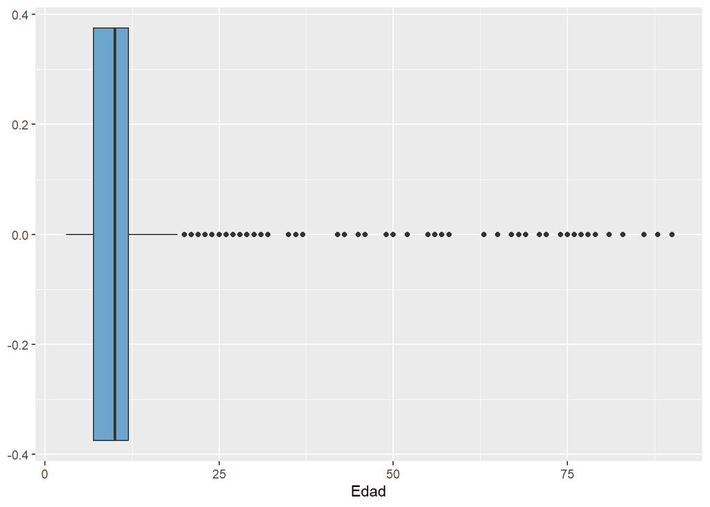

```r
ED %>% ggplot(aes(ED$Edad)) +
  geom_boxplot(fill="skyblue3") +
  labs(x="Edad",y = NULL)+
  theme(plot.title = element_text(hjust = 0.1))
```

Se puede observar que la probabilidad de que al escoger al azar a una persona para la entrevista, la probabilidad de que sea del genero masculino es de 0.57, y esta es superior al que escoger una persona del genero femenino. Esto se puede corroborar realizando las misma funcionalidad:

```r
# Total de personas del genero femenino
cantidad_mujeres <- (EDP %>% filter(Genero == 'Mujer') %>% nrow())
cantidad_mujeres
```

```
## [1] 708
```

```r
S1<-(EDP %>% filter(Genero == 'Mujer') %>% nrow())/(EDP %>% nrow())
S1
```

```
## [1] 0.4293511
```

Finalmente se pudo corrobar lo mencionado anteriormente

- Se quiere saber la probabilidad de escoger al azar a un participante que no tenga una discapacidad física
  $$P(A)=
  \frac{944}{1649}=0.5724682$$

```r
#
P2<-(EDP %>% filter(Discapacidad_Fisica == 'No') %>% nrow())/(EDP %>% nrow())
P2
```

```
## [1] 0.5724682
```

- Se quiere saber la probabilidad de que se encuentren personas menores a 20 años y tengan tengan una limitacion permanente para aprender
  $$P(A)=
  \frac{724}{1547}=0.4680026$$

```r
#
P3<-(EDP %>% filter(Edad < 20 & Limitacion_permanente_aprender == 'Si') %>% nrow())/(EDP %>% filter(Edad<20) %>%nrow())
P3
```

```
## [1] 0.4680026
```

- Se quiere saber la probabilidad de que se encuentren personas mayores a 15 años y asista a un colegio con profesores especializados
  $$P(A)=
  \frac{83}{180}=0.4611111$$

```r
#
P4<-(EDP %>% filter(Edad > 15 & Colegio_con_profesores_especializados == 'Si') %>% nrow())/(EDP %>% filter(Edad>15) %>%nrow())
P4
```

```
## [1] 0.4611111
```

**Para poder corroborar que hicimos de manera correcta nuestra probabilidad tendremos que obtener los demás resultados**

- Probabilidad de que se encuentren personas mayores a 15 años y no asistan a un colegio con profesores especializados

$$P(A)= \frac{54}{180}=0.3$$

```r
#
P5<-(EDP %>% filter(Edad > 15 & Colegio_con_profesores_especializados == 'No') %>% nrow())/(EDP %>% filter(Edad>15) %>%nrow())
P5
```

```
## [1] 0.3
```

- Probabilidad de que se encuentren personas mayores a 15 años y no saben sobre los colegios con profesores especializados
  $$P(A)= \frac{43}{180}=0.2388889$$

```r
#
P6<-(EDP %>% filter(Edad > 15 & Colegio_con_profesores_especializados == 'NEP') %>% nrow())/(EDP %>% filter(Edad>15) %>%nrow())
P6
```

```
## [1] 0.2388889
```

**Sumamos las probabilidades obtenidas en cada situación dicha anteriormente**
$$Suma = P(4) + P(5) + P(6)= 1$$

```r
# Obtenemos una suma a 1 por lo que esta correcto nuestra probabilidad
P4+P5+P6
```

```
## [1] 1
```

### **VARIABLES ALEATORIAS**

#### **Binomial**

Caso 1: En nuestra base de datos contamos con múltiples edades dentro de estas, en su mayoría tenemos personas de la edad de 8 años

```r
mode(EDP$Edad)
```

```
## [1] "numeric"
```

La cantidad de personas que tienen esta edad es de 190

```r
c_p <-(EDP %>% filter(Edad == 8) %>% nrow())
c_p
```

```
## [1] 190
```

La probabilidad de que estas personas tengan una discapacidad física es de:
$$P(A)=
\frac{78}{190}=0.4105263$$

```r
P7<-(EDP %>% filter(Edad ==8 & Discapacidad_Fisica == 'Si') %>% nrow())/(EDP %>% filter(Edad==8) %>%nrow())
P7
```

```
## [1] 0.4105263
```

Calcular la probabilidad de que exactamente 120 personas tengan una discapacidad fisica

```r
n=190
p=0.41
valor=120
dbinom(valor,size=n,prob=p)
```

```
## [1] 0.0000000003765257
```

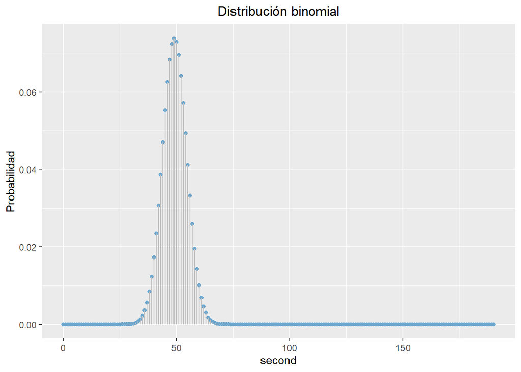

```r
data_binomial <- data.frame(first = dbinom(0:190,120,0.41),second = 0:190)
data_binomial %>% ggplot(aes(x=second,y=first))+
                geom_point(color="skyblue3")+
                geom_segment( aes(x=second, xend=second, y=0, yend=first), color="grey")+
                labs(title="Distribución binomial",y="Probabilidad")+
                theme(plot.title = element_text(hjust = 0.5))
```